# 市场观察

2017/04/07

## A、指数估值

### (a)动态市盈率、市净率

核心指数成分股近18个月的动态市盈率及动态市净率中位数走势如下图所示：

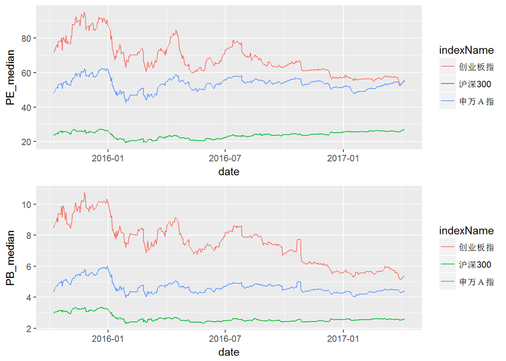

### (b)动态市盈率、市净率百分位

核心指数近18个月的动态市盈率百分位及动态市净率百分位走势如下图所示：

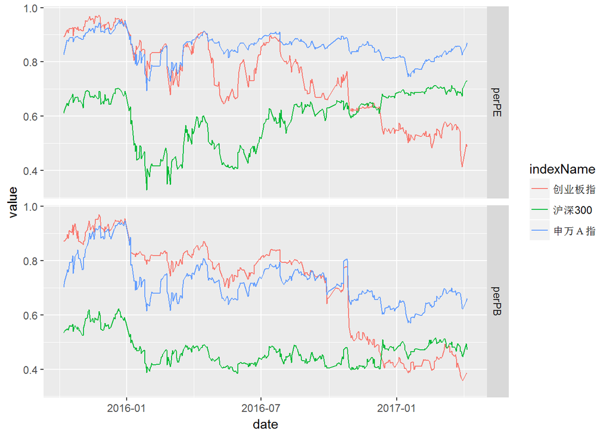

### (c)指数估值概览

| 指数代码 | 指数简称 | 日期 | 动态市盈率 | 市盈率百分位 | 动态市净率 | 市净率百分位 |
| --- | --- | --- | --- | --- | --- | --- |
| EI000819 | 有色金属 | 2017-04-06 | 65.7 | 92% | 3.7 | 72% |
| EI000979 | 大宗商品 | 2017-04-06 | 54.3 | 94% | 2.9 | 66% |
| EI801003 | 申万Ａ指 | 2017-04-06 | 55.1 | 87% | 4.4 | 66% |
| EI399330 | 深证100 | 2017-04-06 | 34.9 | 76% | 4.1 | 65% |
| EI399959 | 军工指数 | 2017-04-06 | 87.4 | 69% | 5.7 | 71% |
| EI000300 | 沪深300 | 2017-04-06 | 26.9 | 73% | 2.6 | 47% |
| EI000905 | 中证500 | 2017-04-06 | 41.9 | 72% | 3.2 | 45% |
| EI399005 | 中小板指P | 2017-04-06 | 41.6 | 65% | 4.7 | 46% |
| EI000934 | 中证金融 | 2017-04-06 | 20.1 | 69% | 1.9 | 24% |
| EI000827 | 中证环保 | 2017-04-06 | 40.4 | 58% | 3.2 | 30% |
| EI399006 | 创业板指 | 2017-04-06 | 55.2 | 49% | 5.4 | 38% |
| EI000922 | 中证红利 | 2017-04-06 | 17.2 | 53% | 1.8 | 34% |
| EI000016 | 上证50 | 2017-04-06 | 18.8 | 68% | 1.6 | 16% |
| EI000998 | 中证TMT | 2017-04-06 | 42.5 | 42% | 4.3 | 36% |
| EI000933 | 中证医药 | 2017-04-06 | 39.7 | 65% | 3.9 | 7% |
| EI000932 | 中证消费 | 2017-04-06 | 30.6 | 39% | 3.8 | 22% |

### (d)另类估值

我国10年期国债收益率、金银比价、金油比价，2000年以来的历史百分位如下图所示：

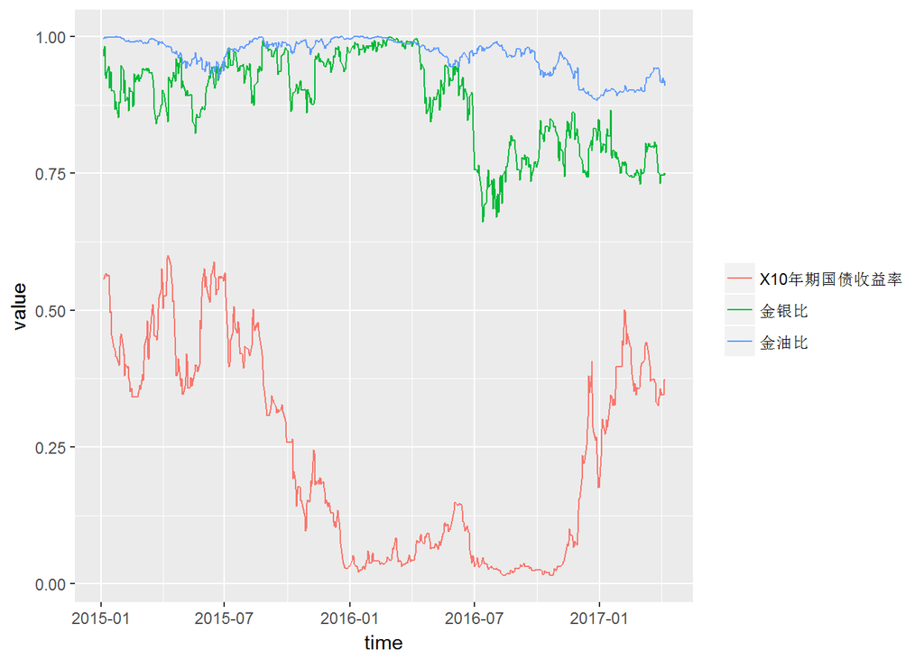

## B、基差

### (a)基差走势

三大股指期货合约基差走势如下图，其中当月合约和次月合约年化基差百分比波动较大，仅展示合约基差百分比，当季合约和次季合约展示基差年化百分比：

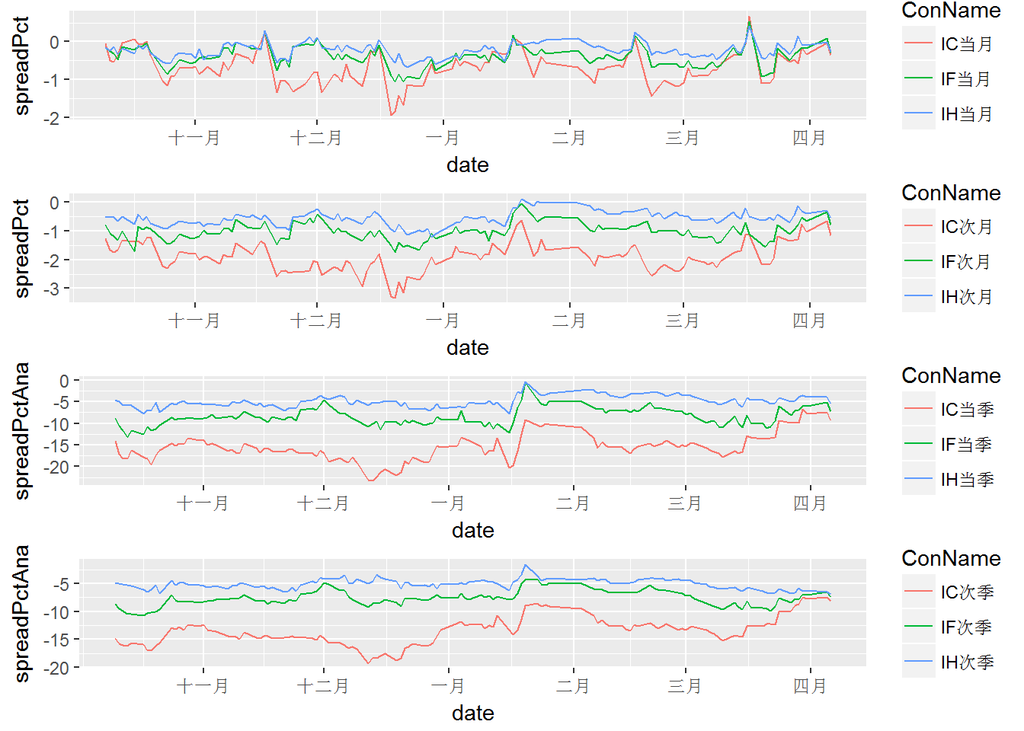

### (b)基差概况

三大股指期货连续合约基差概况如下表，近月合约临近到期日，年化基差百分比数据波动较大：

| 日期 | 合约代码 | 合约收盘价 | 指数收盘价 | 基差 | 基差百分比 | 年化基差百分比 |
| --- | --- | --- | --- | --- | --- | --- |
| 2017-04-06 | IC1704 | 6536.0 | 6559.7 | -23.7 | -0.4% | -9.2% |
| 2017-04-06 | IC1705 | 6482.4 | 6559.7 | -77.3 | -1.2% | -10.4% |
| 2017-04-06 | IC1706 | 6444.6 | 6559.7 | -115.1 | -1.8% | -9.4% |
| 2017-04-06 | IC1709 | 6329.2 | 6559.7 | -230.5 | -3.5% | -8.1% |
| 2017-04-06 | IF1704 | 3504.0 | 3514.0 | -10.0 | -0.3% | -7.2% |
| 2017-04-06 | IF1705 | 3486.4 | 3514.0 | -27.6 | -0.8% | -6.9% |
| 2017-04-06 | IF1706 | 3465.8 | 3514.0 | -48.2 | -1.4% | -7.3% |
| 2017-04-06 | IF1709 | 3400.6 | 3514.0 | -113.4 | -3.2% | -7.4% |
| 2017-04-06 | IH1704 | 2384.0 | 2390.4 | -6.4 | -0.3% | -6.7% |
| 2017-04-06 | IH1705 | 2377.2 | 2390.4 | -13.2 | -0.6% | -4.8% |
| 2017-04-06 | IH1706 | 2365.6 | 2390.4 | -24.8 | -1.0% | -5.4% |
| 2017-04-06 | IH1709 | 2319.0 | 2390.4 | -71.4 | -3.0% | -6.9% |

## C、套利和事件

### (a)复牌股票套利

近两天复牌股票套利情况如下表：

[1] “No valuation adjustment!” [1] “无复牌股票套利”

### (b)定增基金(provided by han.qian)

截止2017-04-07定增基金数据如下表，明细数据参见钱瀚的模板。

| 代码 | 名称 | 到期日期 | 最新净值 | 昨日收盘价 | 折溢价率 | 整体隐含折价率 | 大盘下跌0.1净值变化 |
| --- | --- | --- | --- | --- | --- | --- | --- |
| 168101.OF | 九泰锐智 | 20200814 | 1.25 | 1.09 | -12.2% | 4.4% | -9.5% |
| 168102.OF | 九泰锐富 | 20210204 | 1.05 | 0.91 | -13.8% | 4.2% | -5.1% |
| 501015.OF | 财通升级 | 20170908 | 1.08 | 1.03 | -4.3% | 3.1% | -8.6% |
| 160518.OF | 博时睿远 | 20171016 | 1.01 | 0.96 | -5.3% | 2.7% | -5.8% |

定增基金近期的净值走势如下图：

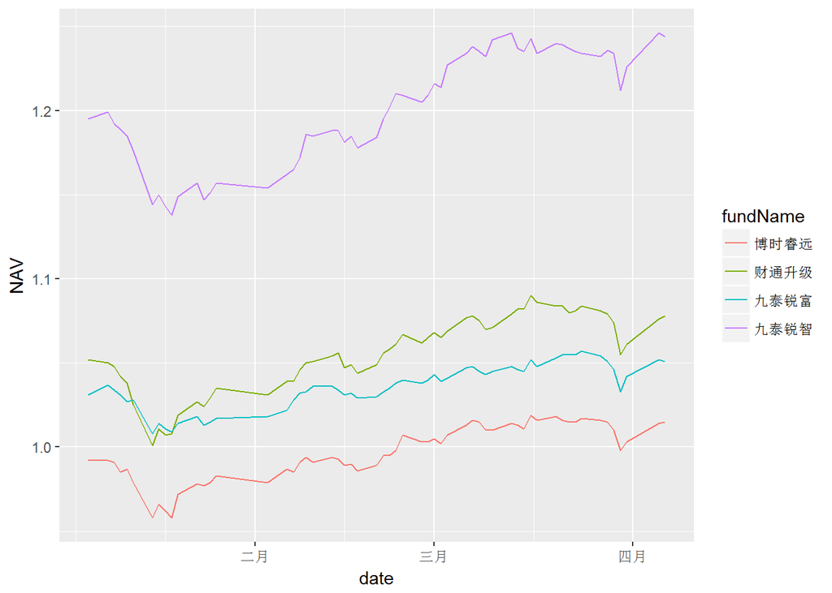

定增基金近期的折溢价率百分比走势如下图：

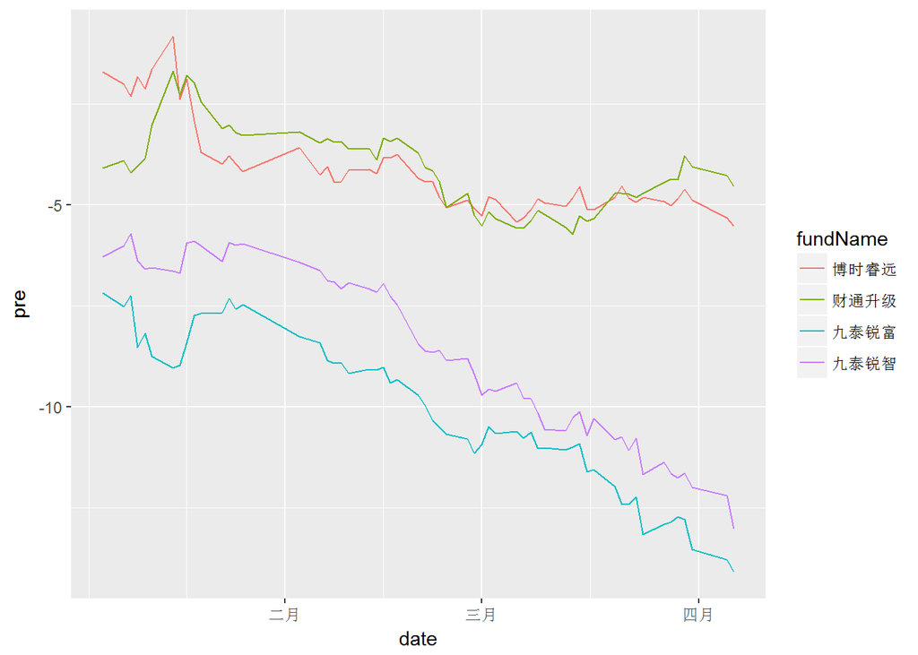

### (c)定增解禁(provided by han.qian)

近十天定增解禁的股票情况如下表。

| 股票代码 | 股票简称 | 起始跟踪日 | 解禁日 | 解禁百分比 | 区间涨跌幅 | 所属行业指数 | 行业指数涨跌幅 |
| --- | --- | --- | --- | --- | --- | --- | --- |
| EQ000701 | 厦门信达 | 2017-03-21 | 2017-04-06 | 6% | -2.3% | 申万电子 | 0.9% |
| EQ002722 | 金轮股份 | 2017-03-21 | 2017-04-06 | 23% | -21.6% | 申万机械设备 | 0.3% |
| EQ002441 | 众 业 达 | 2017-03-22 | 2017-04-07 | 16% | -0.9% | 申万电气设备 | -0.4% |
| EQ300250 | 初灵信息 | 2017-03-22 | 2017-04-07 | 5% | -5.2% | 申万通信 | -2.5% |
| EQ000400 | 许继电气 | 2017-03-23 | 2017-04-10 | 37% | 7.1% | 申万电气设备 | -0.1% |
| EQ000415 | 渤海金控 | 2017-03-23 | 2017-04-10 | 14% | 2.5% | 申万非银金融 | 1.1% |
| EQ000591 | 太 阳 能 | 2017-03-23 | 2017-04-10 | 22% | 1.5% | 申万电气设备 | -0.1% |
| EQ000725 | 京东方Ａ | 2017-03-23 | 2017-04-10 | 41% | 7.5% | 申万电子 | 0.3% |
| EQ002505 | 大康农业 | 2017-03-23 | 2017-04-10 | 255% | 0.0% | 申万农林牧渔 | -0.0% |
| EQ002706 | 良信电器 | 2017-03-23 | 2017-04-10 | 9% | -2.5% | 申万电气设备 | -0.1% |
| EQ300043 | 星辉娱乐 | 2017-03-23 | 2017-04-10 | 9% | -1.2% | 申万传媒 | -1.5% |
| EQ600812 | 华北制药 | 2017-03-23 | 2017-04-10 | 18% | 2.9% | 申万医药生物 | -1.2% |
| EQ000681 | 视觉中国 | 2017-03-27 | 2017-04-12 | 42% | 0.6% | 申万传媒 | -2.2% |
| EQ600177 | 雅 戈 尔 | 2017-03-27 | 2017-04-12 | 15% | -0.8% | 申万纺织服装 | -1.8% |
| EQ000735 | 罗 牛 山 | 2017-03-28 | 2017-04-13 | 20% | -3.7% | 申万农林牧渔 | -0.3% |
| EQ600900 | 长江电力 | 2017-03-28 | 2017-04-13 | 18% | -0.6% | 申万公用事业 | 2.0% |
| EQ002071 | 长城影视 | 2017-03-29 | 2017-04-14 | 57% | -1.0% | 申万传媒 | -1.4% |
| EQ002139 | 拓邦股份 | 2017-03-29 | 2017-04-14 | 14% | -1.1% | 申万电子 | -0.5% |
| EQ000733 | 振华科技 | 2017-03-30 | 2017-04-17 | 9% | 0.0% | 申万电子 | 0.3% |
| EQ002027 | 分众传媒 | 2017-03-30 | 2017-04-17 | 14% | 3.0% | 申万传媒 | -0.5% |
| EQ300310 | 宜通世纪 | 2017-03-31 | 2017-04-18 | 13% | 6.6% | 申万通信 | 2.4% |
| EQ002380 | 科远股份 | 2017-04-05 | 2017-04-19 | 18% | 2.5% | 申万计算机 | 2.6% |
| EQ000961 | 中南建设 | 2017-04-06 | 2017-04-20 | 27% | -0.5% | 申万房地产 | 0.7% |
| EQ000979 | 中弘股份 | 2017-04-06 | 2017-04-20 | 30% | 0.0% | 申万房地产 | 0.7% |
| EQ300388 | 国祯环保 | 2017-04-06 | 2017-04-20 | 17% | -0.6% | 申万公用事业 | 0.5% |
| EQ000606 | 神州易桥 | 2017-04-07 | 2017-04-21 | 8% | 0.0% | 申万医药生物 | 0.0% |
| EQ002546 | 新联电子 | 2017-04-07 | 2017-04-22 | 18% | 0.0% | 申万电气设备 | 0.0% |
| EQ300304 | 云意电气 | 2017-04-07 | 2017-04-21 | 13% | 0.0% | 申万汽车 | 0.0% |

### (d)中小板业绩预增预测(provided by han.qian)

中小板规定正式财务报告发布的同时需要发布新一期的业绩预报，比如年报中会包含一季报预告的情况。我们假设公司的盈利状况有动量效应，年报预增的公司一季度也会预增，在正式财务报告发布前20个交易日开始埋伏，然后等正式报告发布日卖出。具体研究参见钱瀚前期的研究。需要注意的是这里的收益率仅做展示，仅仅是每日全部入选股票的平均收益率，并没有做成一个事件组合。

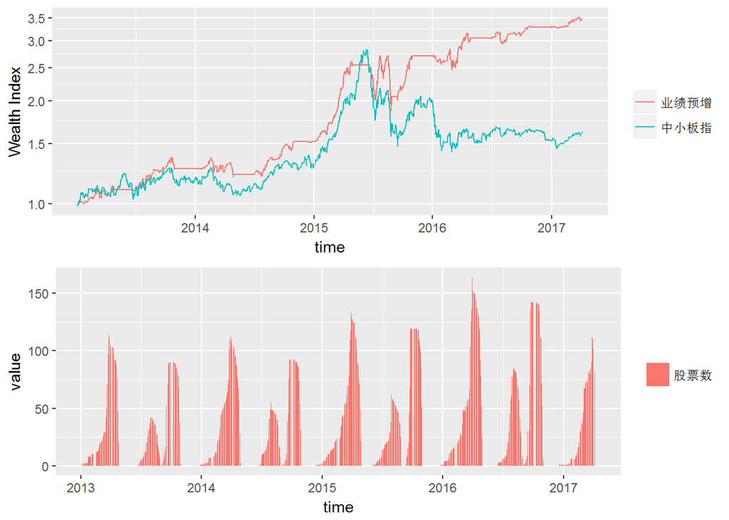

历年收益统计如下表所示。

|  | 业绩预增 | 中小板指 |
| --- | --- | --- |
| 2013-01-04 ~ 2013-12-31 | 26.6% | 17.5% |
| 2014-01-02 ~ 2014-12-31 | 20.1% | 9.7% |
| 2015-01-05 ~ 2015-12-31 | 77.9% | 53.7% |
| 2016-01-04 ~ 2016-12-30 | 22.0% | -22.9% |
| 2017-01-03 ~ 2017-04-06 | 5.7% | 6.2% |
| Cumulative Return | 248.8% | 62.2% |
| Annualized Return | 34.1% | 12.0% |

## D、择时

### (a)等权指数

从历史来看，A股市场存在小盘股效应，市值小的股票长期整体跑赢大市值的股票，美股市场同样存在类似的现象。而目前大部分指数的编制方案都是类似市值加权，为了抛去市值的影响，下面展示几个等权指数，其中中证500等权和沪深300等权是现有的指数，中证全指等权是自己编制的指数。等权指数可以视为一个更好地业绩比较基准。等权指数走势如下图：

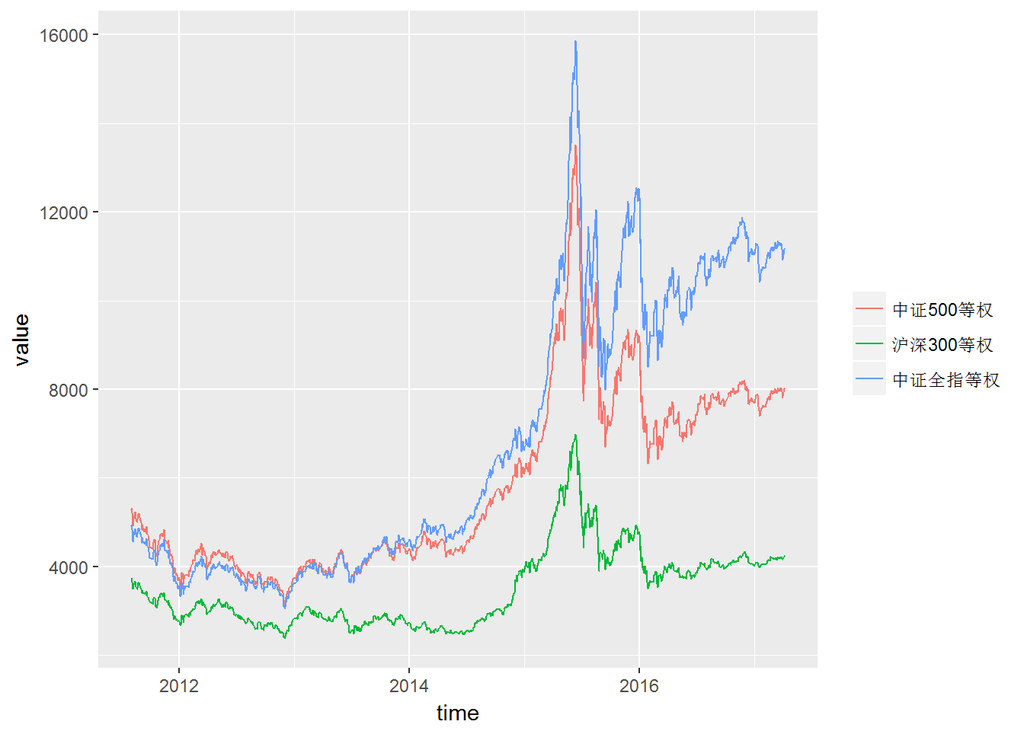

等权指数收益率统计见下表：

|  | 中证500等权 | 沪深300等权 | 中证全指等权 |
| --- | --- | --- | --- |
| 2011-08-02 ~ 2011-12-30 | -29.2% | -25.5% | -27.8% |
| 2012-01-04 ~ 2012-12-31 | -0.0% | 1.5% | 2.2% |
| 2013-01-04 ~ 2013-12-31 | 16.7% | -3.2% | 25.8% |
| 2014-01-02 ~ 2014-12-31 | 40.2% | 43.7% | 46.0% |
| 2015-01-05 ~ 2015-12-31 | 47.6% | 20.1% | 84.4% |
| 2016-01-04 ~ 2016-12-30 | -15.1% | -15.1% | -10.3% |
| 2017-01-03 ~ 2017-04-06 | 4.3% | 5.6% | 1.3% |
| 累计收益率 | 51.4% | 13.4% | 127.1% |
| 年化收益率 | 7.6% | 2.2% | 15.5% |
| 年化波动率 | 28.7% | 26.0% | 29.1% |
| 年化Sharpe值 | 26.4% | 8.6% | 53.4% |
| 最大回撤 | 53.3% | 50.0% | 49.7% |

### (b)大盘均线强弱指数

大盘均线强弱指数在一定程度上可以视为一个反转指标，当大盘均线得分接近8分时，预示市场接近顶部，当大盘均线得分接近0分时，预示市场接近底部。  
大盘均线强弱指数近一年来走势如下图：

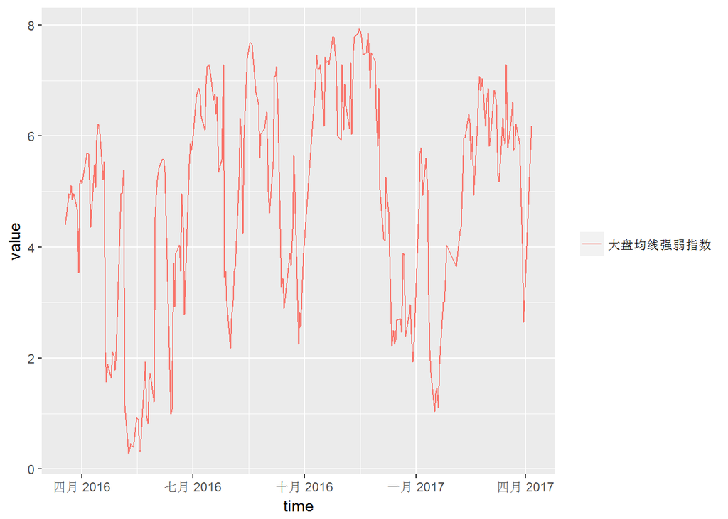

申万一级行业的最新得分见下表：

| 日期 | 指数代码 | 行业 | 最新得分 | 上周得分 |
| --- | --- | --- | --- | --- |
| 2017-04-06 | EI801020 | 采掘 | 8 | 2 |
| 2017-04-06 | EI801030 | 化工 | 8 | 4 |
| 2017-04-06 | EI801040 | 钢铁 | 8 | 4 |
| 2017-04-06 | EI801050 | 有色金属 | 8 | 4 |
| 2017-04-06 | EI801080 | 电子 | 8 | 7 |
| 2017-04-06 | EI801110 | 家用电器 | 8 | 7 |
| 2017-04-06 | EI801120 | 食品饮料 | 8 | 6 |
| 2017-04-06 | EI801160 | 公用事业 | 8 | 4 |
| 2017-04-06 | EI801170 | 交通运输 | 8 | 8 |
| 2017-04-06 | EI801180 | 房地产 | 8 | 1 |
| 2017-04-06 | EI801210 | 休闲服务 | 8 | 8 |
| 2017-04-06 | EI801710 | 建筑材料 | 8 | 8 |
| 2017-04-06 | EI801720 | 建筑装饰 | 8 | 8 |
| 2017-04-06 | EI801730 | 电气设备 | 8 | 5 |
| 2017-04-06 | EI801740 | 国防军工 | 8 | 5 |
| 2017-04-06 | EI801880 | 汽车 | 8 | 5 |
| 2017-04-06 | EI801890 | 机械设备 | 8 | 6 |
| 2017-04-06 | EI801150 | 医药生物 | 6 | 5 |
| 2017-04-06 | EI801780 | 银行 | 6 | 2 |
| 2017-04-06 | EI801010 | 农林牧渔 | 5 | 0 |
| 2017-04-06 | EI801140 | 轻工制造 | 5 | 5 |
| 2017-04-06 | EI801200 | 商业贸易 | 3 | 2 |
| 2017-04-06 | EI801750 | 计算机 | 3 | 2 |
| 2017-04-06 | EI801770 | 通信 | 3 | 3 |
| 2017-04-06 | EI801130 | 纺织服装 | 2 | 2 |
| 2017-04-06 | EI801230 | 综合 | 2 | 1 |
| 2017-04-06 | EI801790 | 非银金融 | 2 | 0 |
| 2017-04-06 | EI801760 | 传媒 | 0 | 0 |

### (c)LLT及均线择时

LLT本质上是一个改进的单均线择时指标，较原始的均线择时延迟更低。  
择时模型和指数本身的净值走势如下图：

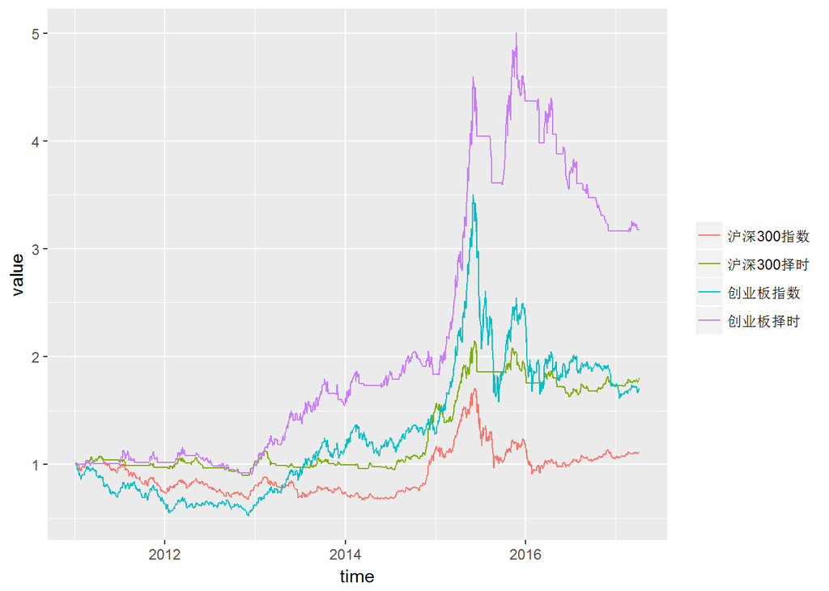

择时模型和指数的收益率统计如下表：

|  | 沪深300指 | 沪深300LLT | 创业板指 | 创业板MA |
| --- | --- | --- | --- | --- |
| 2011-01-04 ~ 2011-12-30 | -25.0% | -2.5% | -35.9% | 1.9% |
| 2012-01-04 ~ 2012-12-31 | 7.6% | 5.4% | -2.1% | -1.7% |
| 2013-01-04 ~ 2013-12-31 | -7.6% | -3.2% | 82.7% | 55.7% |
| 2014-01-02 ~ 2014-12-31 | 51.7% | 52.4% | 12.8% | 17.7% |
| 2015-01-05 ~ 2015-12-31 | 5.6% | 24.3% | 84.4% | 138.1% |
| 2016-01-04 ~ 2016-12-30 | -11.3% | -8.1% | -27.7% | -27.5% |
| 2017-01-03 ~ 2017-04-06 | 6.2% | 3.9% | -0.9% | 0.1% |
| 累计收益率 | 12.3% | 80.2% | 70.9% | 216.9% |
| 年化收益率 | 1.9% | 9.9% | 8.9% | 20.2% |
| 年化波动率 | 24.1% | 15.5% | 32.8% | 22.1% |
| 年化Sharpe值 | 7.8% | 63.8% | 27.3% | 91.6% |
| 最大回撤 | 46.7% | 24.0% | 54.9% | 36.8% |

择时模型最近10个交易日的信号如下表：

| 日期 | 沪深300收盘价 | 沪深300LLT | 沪深300择时信号 | 创业板收盘价 | 创业板MA30 | 创业板择时信号 |
| --- | --- | --- | --- | --- | --- | --- |
| 2017-03-22 | 3450.050 | 3455.100 | hold | 1948.580 | 1934.182 | hold |
| 2017-03-23 | 3461.978 | 3456.374 | hold | 1948.369 | 1935.325 | hold |
| 2017-03-24 | 3489.600 | 3458.852 | hold | 1965.137 | 1937.340 | hold |
| 2017-03-27 | 3478.039 | 3461.710 | hold | 1947.528 | 1938.469 | hold |
| 2017-03-28 | 3469.809 | 3463.764 | hold | 1944.363 | 1939.634 | hold |
| 2017-03-29 | 3465.193 | 3465.279 | hold | 1929.196 | 1940.862 | sell |
| 2017-03-30 | 3436.758 | 3465.624 | hold | 1893.701 | 1940.731 |  |
| 2017-03-31 | 3456.046 | 3465.633 | hold | 1907.338 | 1941.547 |  |
| 2017-04-05 | 3503.893 | 3467.805 | hold | 1943.160 | 1943.153 | buy |
| 2017-04-06 | 3514.047 | 3471.735 | hold | 1944.235 | 1943.925 | hold |

### (d)网格交易

在经历了三轮股灾，A股逐步回归正常，在过去的一段时间呈现一个震荡的格局，如果未来没有增量信息，很可能维持震荡。结合股指期货的贴水，前期研究了一下网格交易。网格交易的结果如下图：

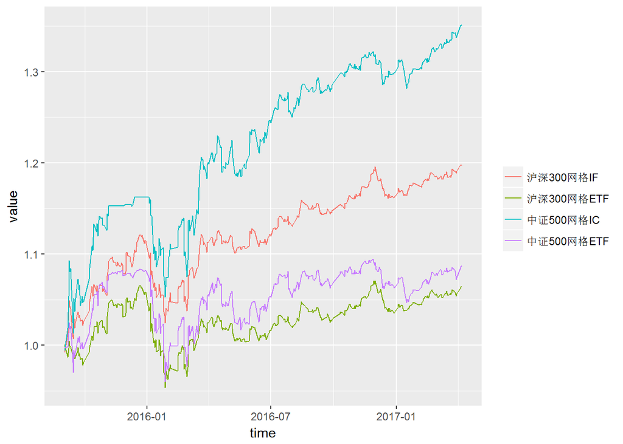

网格交易沪深300股指期货的最新仓位是34.1%，中证500股指期货的最新仓位是37.5%,网格交易的收益统计如下表：

|  | 沪深300指数 | 沪深300网格IF | 沪深300网格ETF | 中证500指数 | 中证500网格IC | 中证500网格ETF |
| --- | --- | --- | --- | --- | --- | --- |
| 2015-09-02 ~ 2015-12-31 | 11.0% | 11.1% | 5.6% | 23.5% | 16.2% | 8.1% |
| 2016-01-04 ~ 2016-12-30 | -11.3% | 4.7% | -1.8% | -17.8% | 11.8% | -1.6% |
| 2017-01-03 ~ 2017-04-07 | 6.3% | 3.0% | 2.7% | 5.0% | 4.0% | 2.2% |
| 累计收益率 | 4.6% | 19.8% | 6.4% | 6.6% | 35.2% | 8.7% |
| 年化收益率 | 2.9% | 11.9% | 4.0% | 4.1% | 20.7% | 5.4% |
| 年化波动率 | 21.8% | 9.1% | 8.9% | 29.3% | 13.4% | 11.4% |
| 年化Sharpe值 | 13.2% | 131.0% | 44.7% | 14.0% | 154.5% | 47.1% |
| 最大回撤 | 26.4% | 8.6% | 10.5% | 33.5% | 9.4% | 11.4% |

## E、选股

### (a)超级小盘股

作为多因子选股的第一部分，有必要从市值因子说起。 下面利用总市值因子，在中证全指的成分股内，选出市值最小的100只股票，这里剔除了ST、新上市、停牌和涨停的股票，100只股票等权配置，每月换仓一次，交易成本千分之三。超级小盘股策略的净值表现如下图。

[output not shown]

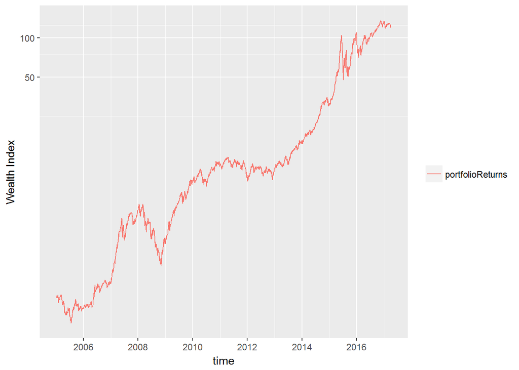

超级小盘股的收益统计如下表：

|  | 超级小盘股 | 沪深300 | 中证500 |
| --- | --- | --- | --- |
| 2005-01-05 ~ 2005-12-30 | -16.7% | -6.0% | -12.8% |
| 2006-01-04 ~ 2006-12-29 | 55.8% | 121.0% | 100.7% |
| 2007-01-04 ~ 2007-12-28 | 265.1% | 161.5% | 186.6% |
| 2008-01-02 ~ 2008-12-31 | -44.5% | -65.9% | -60.8% |
| 2009-01-05 ~ 2009-12-31 | 205.8% | 96.7% | 131.3% |
| 2010-01-04 ~ 2010-12-31 | 32.2% | -12.5% | 10.5% |
| 2011-01-04 ~ 2011-12-30 | -19.4% | -25.0% | -33.8% |
| 2012-01-04 ~ 2012-12-31 | 15.3% | 7.6% | 0.3% |
| 2013-01-04 ~ 2013-12-31 | 63.3% | -7.6% | 16.9% |
| 2014-01-02 ~ 2014-12-31 | 88.8% | 51.7% | 39.0% |
| 2015-01-05 ~ 2015-12-31 | 254.4% | 5.6% | 43.1% |
| 2016-01-04 ~ 2016-12-30 | 21.2% | -11.3% | -17.8% |
| 2017-01-03 ~ 2017-04-06 | -5.4% | 6.2% | 4.7% |
| 累计收益率 | 12267.3% | 257.6% | 566.9% |
| 年化收益率 | 48.2% | 11.0% | 16.7% |
| 年化波动率 | 35.8% | 28.4% | 32.4% |
| 年化Sharpe值 | 134.8% | 38.6% | 51.6% |
| 最大回撤 | 66.3% | 72.3% | 72.4% |

### (b)银行股轮动

银行股轮动是参考集思录的热门贴银行股评级而来的，数据的提取和参数的设置和原贴有一定的差别，所以轮动的效果也会不太一样，不过回测的效果还不错，从现在开始跟踪。2013年以来银行股轮动的结果如下图：

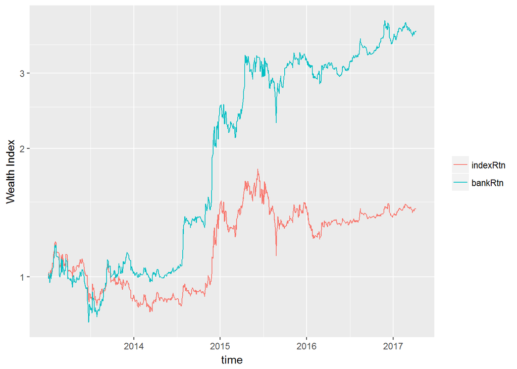

银行股轮动的收益统计如下表：

|  | 申万银行 | 银行股轮动 |
| --- | --- | --- |
| 2013-01-04 ~ 2013-12-31 | -9.2% | 3.0% |
| 2014-01-02 ~ 2014-12-31 | 63.2% | 144.5% |
| 2015-01-05 ~ 2015-12-31 | -1.4% | 29.0% |
| 2016-01-04 ~ 2016-12-30 | -4.9% | 10.5% |
| 2017-01-03 ~ 2017-04-06 | 3.8% | 4.3% |
| 累计收益率 | 44.2% | 274.5% |
| 年化收益率 | 9.0% | 36.3% |
| 年化波动率 | 28.2% | 32.1% |
| 年化Sharpe值 | 31.9% | 113.3% |
| 最大回撤 | 37.4% | 34.2% |

银行股轮动的最新得分如下表：

| 日期 | 代码 | 简称 | PB | 预期ROE | 翻倍期 | 持仓 |
| --- | --- | --- | --- | --- | --- | --- |
| 2017-04-06 | EQ600015 | 华夏银行 | 0.82 | 0.15 | 3.6 | hold |
| 2017-04-06 | EQ601818 | 光大银行 | 0.76 | 0.12 | 3.8 |  |
| 2017-04-06 | EQ601988 | 中国银行 | 0.76 | 0.11 | 4.0 |  |
| 2017-04-06 | EQ601328 | 交通银行 | 0.74 | 0.10 | 4.0 |  |
| 2017-04-06 | EQ601288 | 农业银行 | 0.82 | 0.13 | 4.0 |  |
| 2017-04-06 | EQ000001 | 平安银行 | 0.78 | 0.11 | 4.4 |  |
| 2017-04-06 | EQ601166 | 兴业银行 | 0.90 | 0.14 | 4.4 |  |
| 2017-04-06 | EQ601398 | 工商银行 | 0.87 | 0.13 | 4.5 |  |
| 2017-04-06 | EQ601939 | 建设银行 | 0.95 | 0.14 | 5.0 |  |
| 2017-04-06 | EQ600000 | 浦发银行 | 0.95 | 0.14 | 5.0 |  |
| 2017-04-06 | EQ600016 | 民生银行 | 0.90 | 0.13 | 5.0 |  |
| 2017-04-06 | EQ601998 | 中信银行 | 0.87 | 0.11 | 5.5 |  |
| 2017-04-06 | EQ601169 | 北京银行 | 1.05 | 0.13 | 6.0 |  |
| 2017-04-06 | EQ601009 | 南京银行 | 1.18 | 0.15 | 6.2 |  |
| 2017-04-06 | EQ600036 | 招商银行 | 1.19 | 0.15 | 6.2 |  |
| 2017-04-06 | EQ002142 | 宁波银行 | 1.41 | 0.16 | 6.9 |  |
| 2017-04-06 | EQ600919 | 江苏银行 | 1.38 | 0.13 | 8.4 |  |
| 2017-04-06 | EQ601997 | 贵阳银行 | 1.91 | 0.16 | 9.0 |  |
| 2017-04-06 | EQ601229 | 上海银行 | 1.38 | 0.12 | 9.0 |  |
| 2017-04-06 | EQ600926 | 杭州银行 | 1.71 | 0.10 | 12.5 |  |
| 2017-04-06 | EQ601128 | 常熟银行 | 2.74 | 0.10 | 17.1 |  |
| 2017-04-06 | EQ600908 | 无锡银行 | 2.77 | 0.10 | 17.9 |  |
| 2017-04-06 | EQ603323 | 吴江银行 | 2.76 | 0.08 | 22.1 |  |
| 2017-04-06 | EQ002807 | 江阴银行 | 3.97 | 0.09 | 25.4 |  |

## F、多因子跟踪

### (a)近一个月周频因子IC

全市场因子IC表现如下图所示，根据因子IC均值大于0，胜率大于50%简单区分了一下alpha因子和风险因子。

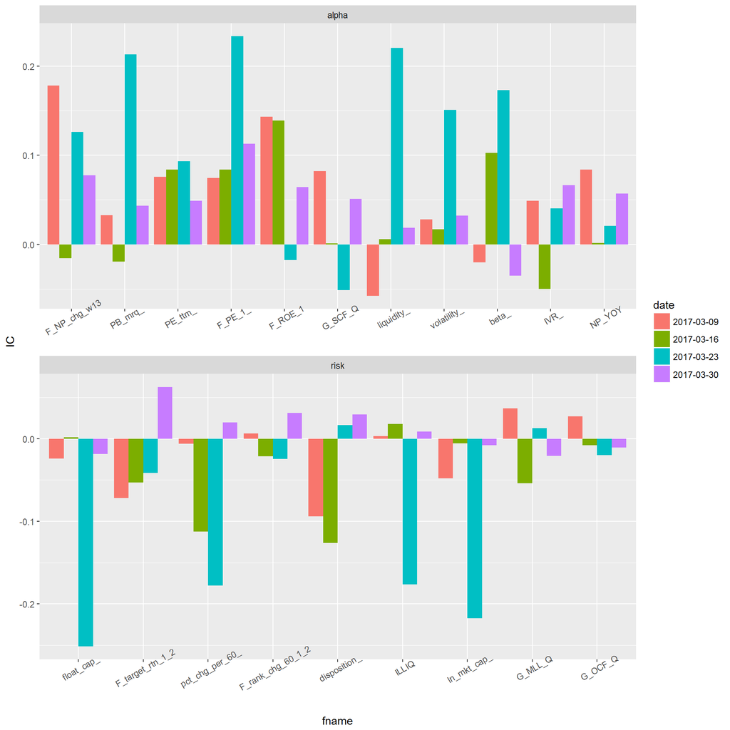

沪深300因子IC表现如下图所示。

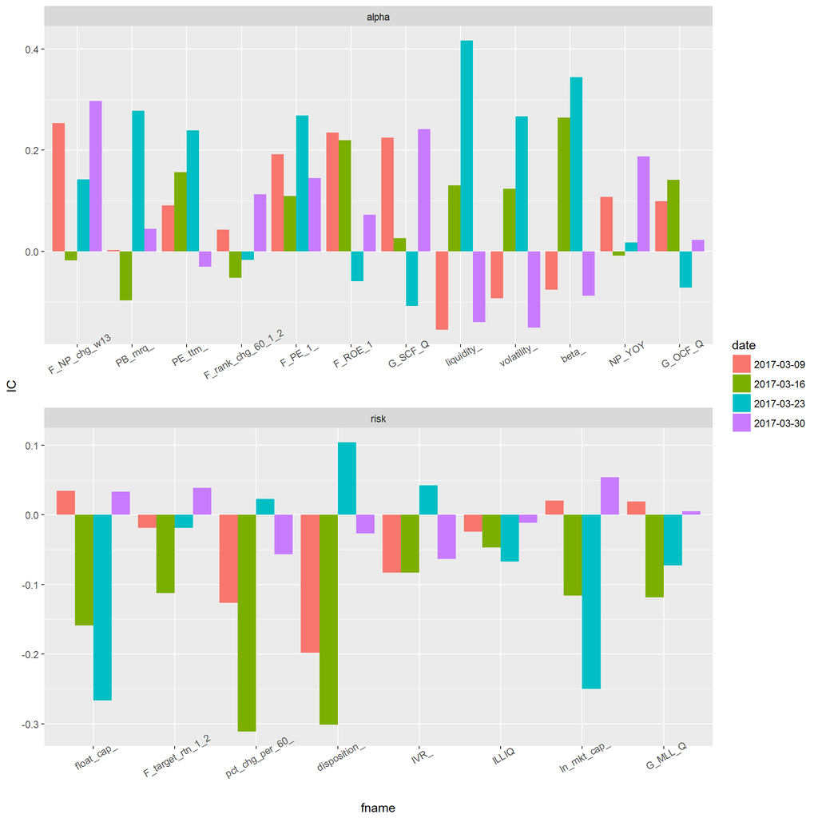

中证500因子IC表现如下图所示。

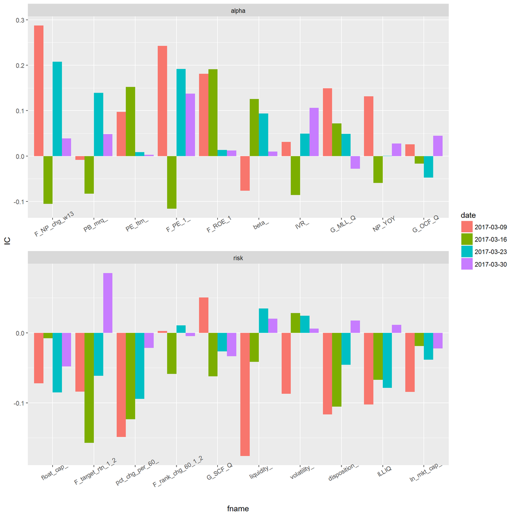

因子IC统计如下表所示。

| 因子名 | 全市场排名 | 全市场均值 | 全市场胜率 | 沪深300排名 | 沪深300均值 | 沪深300胜率 | 中证500排名 | 中证500均值 | 中证500胜率 |
| --- | --- | --- | --- | --- | --- | --- | --- | --- | --- |
| F_PE_1_ | 1 | 0.126 | 1.00 | 1 | 0.179 | 1.00 | 1 | 0.114 | 0.75 |
| F_NP_chg_w13 | 2 | 0.092 | 0.75 | 2 | 0.169 | 0.75 | 2 | 0.107 | 0.75 |
| F_ROE_1 | 3 | 0.082 | 0.75 | 3 | 0.117 | 0.75 | 3 | 0.099 | 1.00 |
| PE_ttm_ | 4 | 0.076 | 1.00 | 4 | 0.114 | 0.75 | 4 | 0.065 | 1.00 |
| PB_mrq_ | 5 | 0.067 | 0.75 | 9 | 0.057 | 0.75 | 9 | 0.024 | 0.50 |
| volatility_ | 6 | 0.057 | 1.00 | 11 | 0.037 | 0.50 | 11 | -0.007 | 0.75 |
| beta_ | 7 | 0.055 | 0.50 | 5 | 0.111 | 0.50 | 6 | 0.038 | 0.75 |
| liquidity_ | 8 | 0.047 | 0.75 | 8 | 0.063 | 0.50 | 14 | -0.041 | 0.50 |
| NP_YOY | 9 | 0.041 | 1.00 | 7 | 0.076 | 0.75 | 8 | 0.025 | 0.75 |
| IVR_ | 10 | 0.026 | 0.75 | 16 | -0.047 | 0.25 | 7 | 0.025 | 0.75 |
| G_SCF_Q | 11 | 0.021 | 0.75 | 6 | 0.096 | 0.75 | 13 | -0.018 | 0.25 |
| F_rank_chg_60_1_2 | 12 | -0.002 | 0.50 | 12 | 0.022 | 0.50 | 12 | -0.013 | 0.50 |
| G_OCF_Q | 13 | -0.003 | 0.25 | 10 | 0.048 | 0.75 | 10 | 0.002 | 0.50 |
| G_MLL_Q | 14 | -0.006 | 0.50 | 15 | -0.042 | 0.50 | 5 | 0.061 | 0.75 |
| F_target_rtn_1_2 | 15 | -0.026 | 0.25 | 13 | -0.028 | 0.25 | 17 | -0.054 | 0.25 |
| ILLIQ | 16 | -0.037 | 0.75 | 14 | -0.037 | 0.00 | 18 | -0.059 | 0.25 |
| disposition_ | 17 | -0.044 | 0.50 | 19 | -0.106 | 0.25 | 19 | -0.063 | 0.25 |
| pct_chg_per_60_ | 18 | -0.069 | 0.25 | 20 | -0.118 | 0.25 | 20 | -0.097 | 0.00 |
| ln_mkt_cap_ | 19 | -0.070 | 0.00 | 17 | -0.073 | 0.50 | 15 | -0.041 | 0.00 |
| float_cap_ | 20 | -0.073 | 0.25 | 18 | -0.089 | 0.50 | 16 | -0.053 | 0.00 |

### (b)近一个月周频因子分组超额收益

全市场，不同时间段，根据因子得分分为10组，得分最高的组**超额**收益率如下图所示，根据累计收益率大于0和区间收益率为正概率大于0.5,简单区分了alpha因子和风险因子。

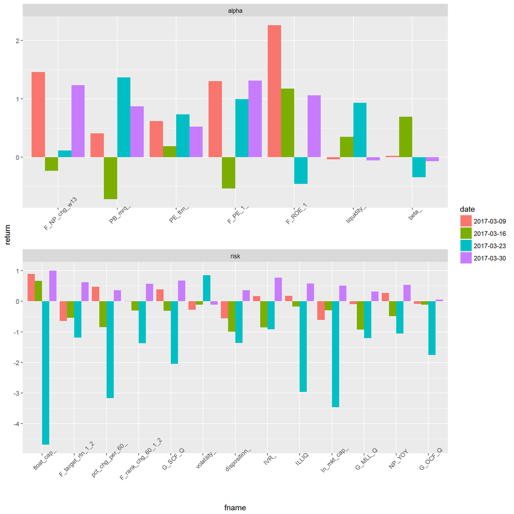

沪深300内得分最高的组**超额**收益率如下图所示。

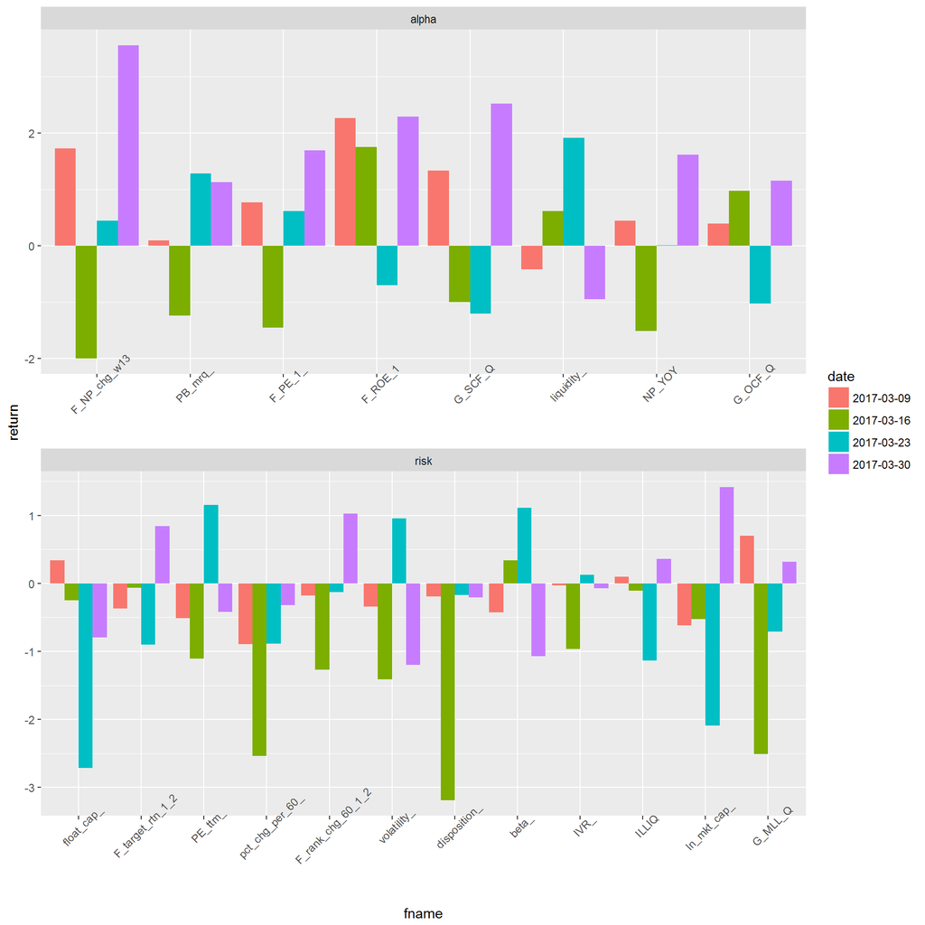

中证500内得分最高的组**超额**收益率如下图所示。

[figure not shown]

各个样本空间内，因子得分最高的一组和得分最低的一组的**超额**累积收益率统计如下表所示。

| 因子名 | 全市场Q1 | 全市场Q10 | 沪深300Q1 | 沪深300Q10 | 中证500Q1 | 中证500Q10 |
| --- | --- | --- | --- | --- | --- | --- |
| F_ROE_1 | 4.1 | -0.6 | 5.7 | 0.1 | 6.4 | 0.6 |
| F_PE_1_ | 3.1 | -2.1 | 1.6 | -2.7 | 5.4 | -1.1 |
| F_NP_chg_w13 | 2.6 | -2.6 | 3.7 | -4.8 | 2.9 | -0.7 |
| PE_ttm_ | 2.1 | -2.4 | -0.9 | -3.4 | 3.7 | -0.9 |
| PB_mrq_ | 1.9 | -3.6 | 1.2 | -0.9 | 2.9 | 0.2 |
| liquidity_ | 1.2 | -4.0 | 1.1 | -1.3 | -0.4 | 1.7 |
| volatility_ | 0.4 | -3.2 | -2.0 | -3.4 | -0.5 | -0.1 |
| beta_ | 0.3 | -3.4 | -0.1 | -4.3 | -0.4 | -3.1 |
| NP_YOY | -0.7 | -2.6 | 0.5 | -3.4 | -0.9 | 0.0 |
| IVR_ | -0.8 | -2.2 | -0.9 | 0.1 | 0.0 | -1.1 |
| F_rank_chg_60_1_2 | -1.1 | -0.6 | -0.6 | -1.4 | -0.3 | -0.2 |
| G_SCF_Q | -1.3 | -2.7 | 1.6 | -3.0 | -1.0 | -0.7 |
| F_target_rtn_1_2 | -1.7 | -0.3 | -0.5 | -0.1 | -2.0 | 0.2 |
| G_MLL_Q | -1.9 | -1.3 | -2.2 | 0.2 | 0.8 | -1.4 |
| G_OCF_Q | -1.9 | -1.4 | 1.5 | -1.9 | -0.2 | -0.4 |
| float_cap_ | -2.2 | 1.6 | -3.4 | 0.3 | -1.5 | 1.9 |
| ILLIQ | -2.4 | 0.8 | -0.8 | -0.1 | -1.4 | 1.2 |
| disposition_ | -2.5 | 0.1 | -3.7 | 1.3 | -3.1 | 2.4 |
| pct_chg_per_60_ | -3.2 | 0.8 | -4.6 | 0.5 | -2.8 | 2.2 |
| ln_mkt_cap_ | -3.8 | 1.3 | -1.8 | 0.8 | 1.3 | 1.6 |

### (c)近一年月频因子IC

全市场因子IC表现如下图所示。

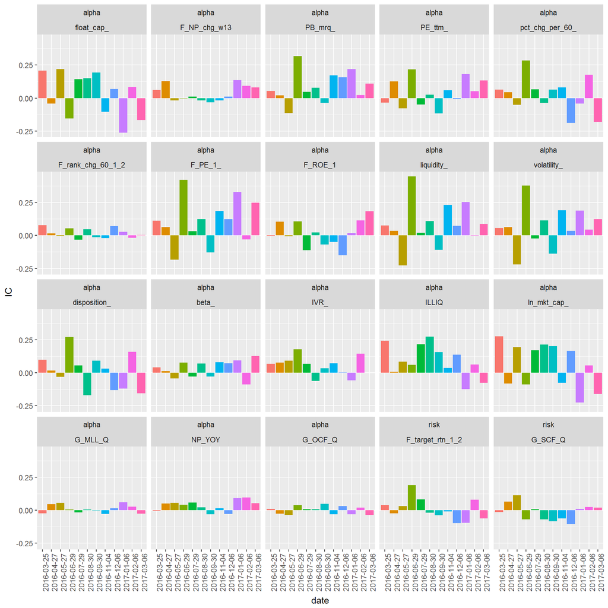

沪深300因子IC表现如下图所示。

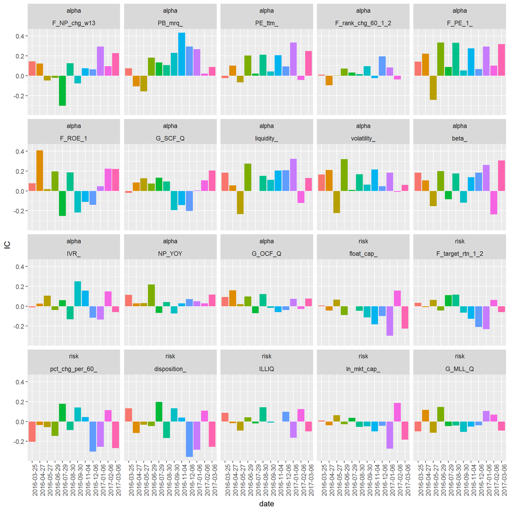

中证500因子IC表现如下图所示。

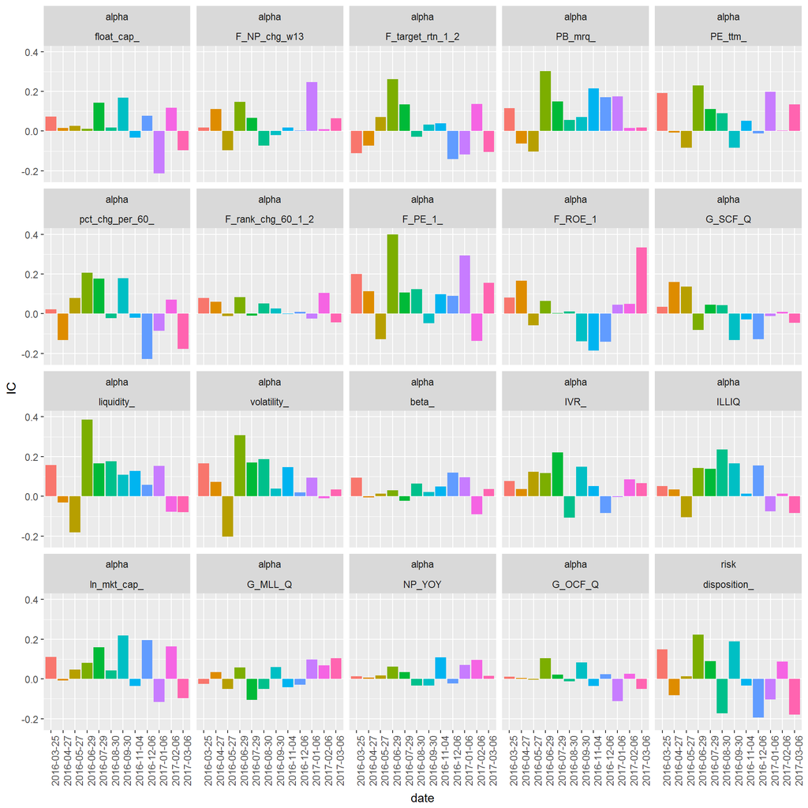

因子IC统计如下表所示。

|  | 因子名 | 全市场排名 | 全市场均值 | 全市场胜率 | 沪深300排名 | 沪深300均值 | 沪深300胜率 | 中证500排名 | 中证500均值 | 中证500胜率 |
| --- | --- | --- | --- | --- | --- | --- | --- | --- | --- | --- |
| 21 | F_PE_1_ | 1 | 0.108 | 0.75 | 1 | 0.165 | 0.92 | 1 | 0.105 | 0.75 |
| 22 | ILLIQ | 2 | 0.090 | 0.83 | 14 | 0.008 | 0.42 | 8 | 0.057 | 0.75 |
| 23 | PB_mrq_ | 3 | 0.087 | 0.83 | 2 | 0.130 | 0.83 | 2 | 0.093 | 0.83 |
| 24 | liquidity_ | 4 | 0.083 | 0.75 | 4 | 0.108 | 0.75 | 4 | 0.080 | 0.67 |
| 25 | volatility_ | 5 | 0.068 | 0.75 | 5 | 0.101 | 0.83 | 3 | 0.085 | 0.83 |
| 26 | ln_mkt_cap_ | 6 | 0.055 | 0.58 | 17 | -0.040 | 0.33 | 6 | 0.063 | 0.67 |
| 27 | IVR_ | 7 | 0.052 | 0.83 | 13 | 0.021 | 0.50 | 7 | 0.061 | 0.75 |
| 28 | PE_ttm_ | 8 | 0.042 | 0.58 | 3 | 0.110 | 0.75 | 5 | 0.068 | 0.67 |
| 29 | F_NP_chg_w13 | 9 | 0.036 | 0.58 | 7 | 0.058 | 0.67 | 9 | 0.041 | 0.75 |
| 30 | NP_YOY | 10 | 0.035 | 0.75 | 9 | 0.049 | 0.83 | 11 | 0.028 | 0.75 |
| 31 | beta_ | 11 | 0.032 | 0.67 | 6 | 0.081 | 0.67 | 10 | 0.034 | 0.75 |
| 32 | float_cap_ | 12 | 0.028 | 0.58 | 19 | -0.073 | 0.25 | 13 | 0.026 | 0.75 |
| 33 | pct_chg_per_60_ | 13 | 0.023 | 0.58 | 20 | -0.073 | 0.33 | 17 | 0.006 | 0.50 |
| 34 | F_rank_chg_60_1_2 | 14 | 0.017 | 0.58 | 11 | 0.029 | 0.75 | 12 | 0.027 | 0.58 |
| 35 | F_ROE_1 | 15 | 0.013 | 0.50 | 8 | 0.055 | 0.67 | 14 | 0.019 | 0.67 |
| 36 | G_MLL_Q | 16 | 0.010 | 0.58 | 15 | -0.013 | 0.33 | 15 | 0.010 | 0.50 |
| 37 | disposition_ | 17 | 0.010 | 0.58 | 18 | -0.054 | 0.42 | 20 | -0.001 | 0.50 |
| 38 | F_target_rtn_1_2 | 18 | 0.007 | 0.42 | 16 | -0.030 | 0.42 | 16 | 0.008 | 0.50 |
| 39 | G_OCF_Q | 19 | 0.000 | 0.58 | 10 | 0.036 | 0.58 | 18 | 0.005 | 0.58 |
| 40 | G_SCF_Q | 20 | -0.014 | 0.50 | 12 | 0.023 | 0.67 | 19 | 0.000 | 0.50 |

### (d)近一年月频因子分组超额收益

全市场，不同时间段，根据因子得分分为10组，得分最高的组**超额**收益率如下图所示，根据累计收益率大于0和区间收益率为正概率大于0.5,简单区分了alpha因子和风险因子。

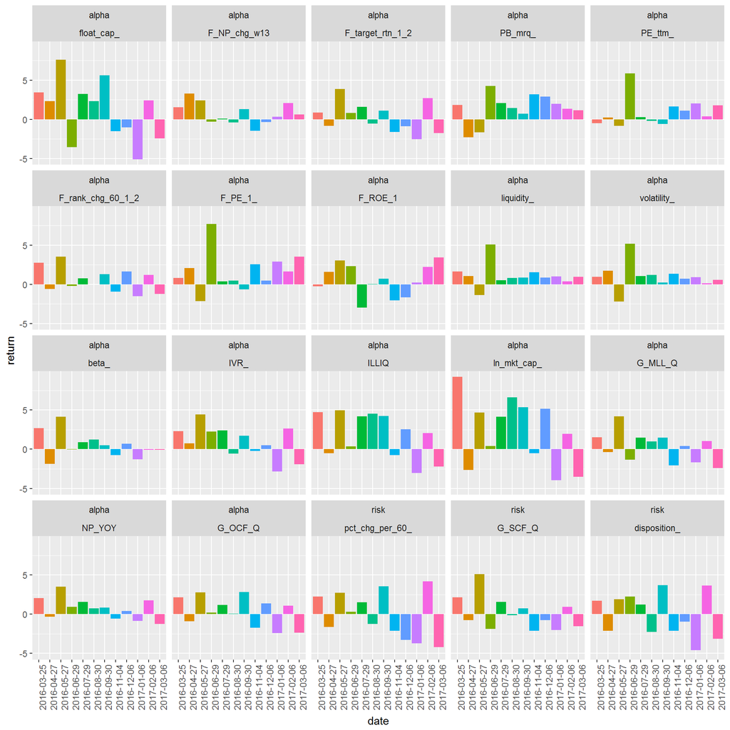

沪深300内得分最高的组**超额**收益率如下图所示。

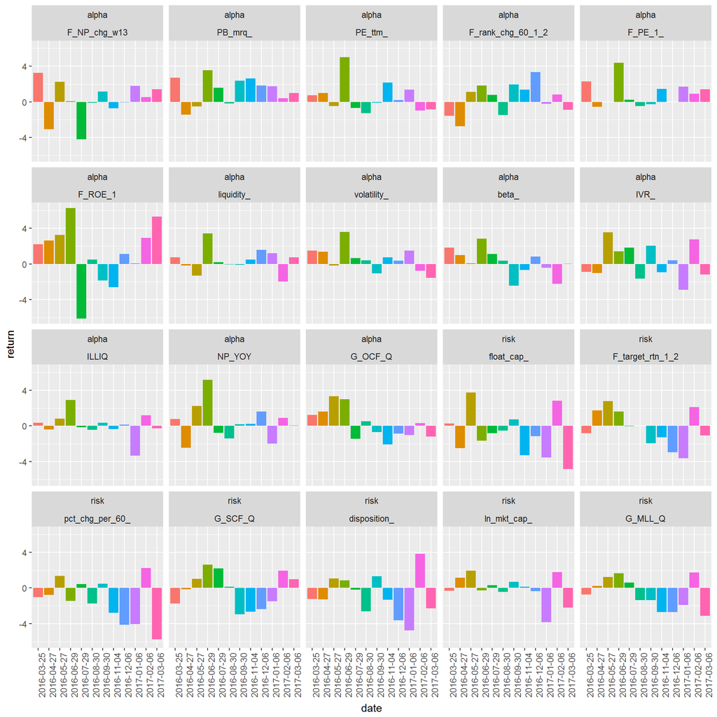

中证500内得分最高的组**超额**收益率如下图所示。

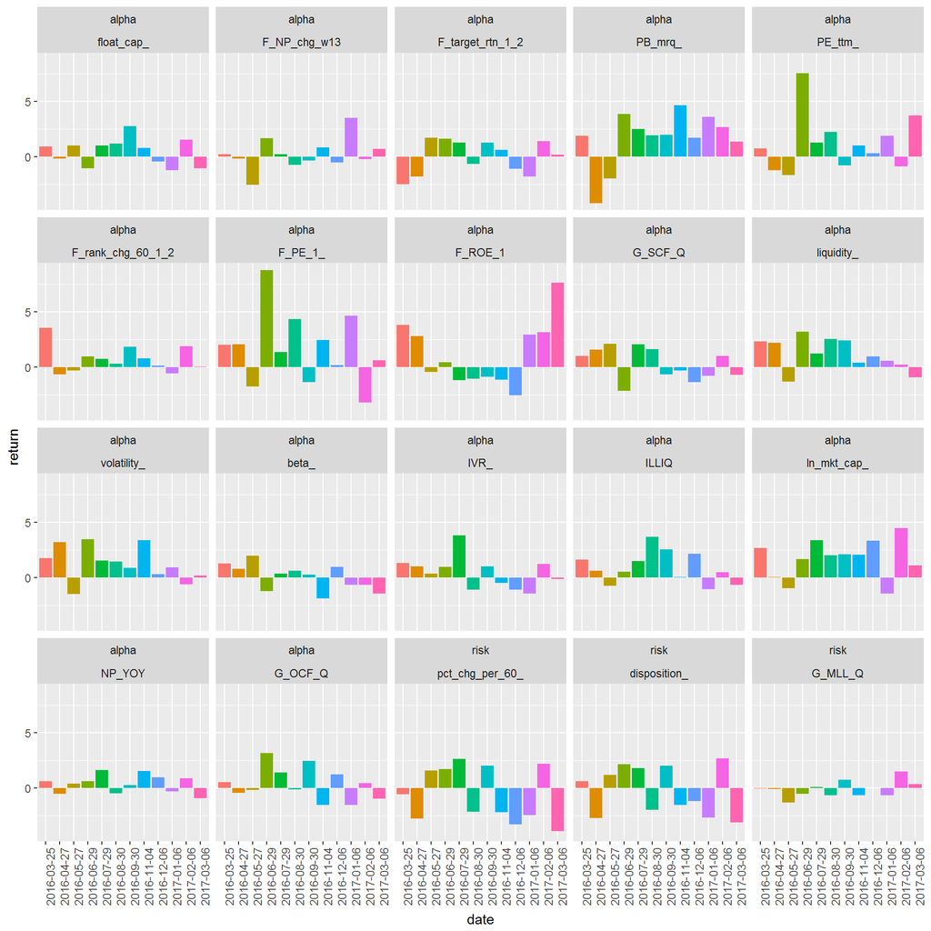

各个样本空间内，因子得分最高的一组和得分最低的一组的**超额**累积收益率统计如下表所示。

|  | 因子名 | 全市场Q1 | 全市场Q10 | 沪深300Q1 | 沪深300Q10 | 中证500Q1 | 中证500Q10 |
| --- | --- | --- | --- | --- | --- | --- | --- |
| 21 | ln_mkt_cap_ | 29.4 | 0.6 | -1.6 | 6.7 | 22.2 | -2.1 |
| 22 | ILLIQ | 22.8 | -9.2 | 0.7 | 4.0 | 11.1 | -10.5 |
| 23 | F_PE_1_ | 21.1 | -11.4 | 11.5 | -14.8 | 21.5 | -10.9 |
| 24 | PB_mrq_ | 18.1 | -13.0 | 16.7 | -18.5 | 21.6 | -12.1 |
| 25 | liquidity_ | 14.0 | -14.7 | 4.6 | -14.5 | 14.7 | -10.3 |
| 26 | float_cap_ | 13.2 | 1.7 | -10.5 | 11.7 | 5.3 | -3.7 |
| 27 | volatility_ | 12.2 | -7.9 | 6.6 | -14.6 | 15.8 | -9.6 |
| 28 | IVR_ | 11.9 | -4.4 | 3.1 | -2.8 | 5.4 | -4.5 |
| 29 | PE_ttm_ | 11.5 | -1.8 | 6.1 | -12.1 | 14.8 | -5.5 |
| 30 | F_NP_chg_w13 | 9.4 | -3.2 | 2.1 | -5.4 | 2.6 | -11.5 |
| 31 | NP_YOY | 9.1 | -1.6 | 4.4 | -4.6 | 4.5 | -1.1 |
| 32 | F_rank_chg_60_1_2 | 6.6 | 1.5 | 4.2 | -4.5 | 9.1 | 2.9 |
| 33 | F_ROE_1 | 6.5 | 2.4 | 13.7 | 5.6 | 13.9 | 7.1 |
| 34 | beta_ | 6.1 | -7.9 | 2.0 | -20.7 | 0.2 | -13.4 |
| 35 | G_OCF_Q | 4.1 | 4.4 | 2.5 | -7.5 | 4.3 | 3.6 |
| 36 | G_MLL_Q | 3.1 | 1.6 | -8.3 | -0.5 | -1.3 | 2.4 |
| 37 | F_target_rtn_1_2 | 2.6 | -0.1 | -3.7 | 1.5 | 0.2 | -0.4 |
| 38 | G_SCF_Q | 1.1 | 6.5 | -2.7 | -9.0 | 3.4 | -1.9 |
| 39 | disposition_ | -1.1 | -8.2 | -10.2 | 0.3 | -3.0 | -7.9 |
| 40 | pct_chg_per_60_ | -2.0 | -8.2 | -16.2 | 6.2 | -7.3 | -9.2 |